# Superstore2

## Superstore data set

### This script contains the following:

#### 1. Importing Visualization Libraries and Data

#### 2. Data Cleaning

#### 3. Exploring Relationships

```
 Correlations
 Scatterplots
 Pair Plots
 Categorical Plots
```

### 1. Importing Visualizations and libraries and Data

```python
# import necessary libraries
import pandas as pd
import numpy as np
import os
import matplotlib.pyplot as plt
import seaborn as sns
import sys
import folium
import json

# !{sys.executable} -m pip install pandas-profiling
# !jupyter nbextension enable --py widgetsnbextension
```

```python
# This command propts matplotlib visuals to appear in the notebook

%matplotlib inline
```

```python
# Import ".json" file for the U.S.

country_geo = r'/Users/margoshogren/Library/CloudStorage/OneDrive-Personal/Documents/Margo-CF Folder-OD/A6 Adv Analytics and Dashboard design/6_3 Geographical visualizations with Python/us-states.json'
```

### Load the Superstore CSV file; note encoding is needed

```python
path = r'/Users/margoshogren/Desktop/1 Margo-CF Folder -desktop/4 Python/4-2023 Instacart Basket Analysis'
```

```python
SS = pd.read_csv(os.path.join(path,'Superstore','Superstore.csv'), encoding = 'Latin-1')
```

### Check what is in the data

```python
SS.describe()
```

|  | Row ID | Postal Code | Sales | Quantity | Discount | Profit |
| --- | --- | --- | --- | --- | --- | --- |
| count | 9994.000000 | 9994.000000 | 9994.000000 | 9994.000000 | 9994.000000 | 9994.000000 |
| mean | 4997.500000 | 55190.379428 | 229.858001 | 3.789574 | 0.156203 | 28.656896 |
| std | 2885.163629 | 32063.693350 | 623.245101 | 2.225110 | 0.206452 | 234.260108 |
| min | 1.000000 | 1040.000000 | 0.444000 | 1.000000 | 0.000000 | -6599.978000 |
| 25% | 2499.250000 | 23223.000000 | 17.280000 | 2.000000 | 0.000000 | 1.728750 |
| 50% | 4997.500000 | 56430.500000 | 54.490000 | 3.000000 | 0.200000 | 8.666500 |
| 75% | 7495.750000 | 90008.000000 | 209.940000 | 5.000000 | 0.200000 | 29.364000 |
| max | 9994.000000 | 99301.000000 | 22638.480000 | 14.000000 | 0.800000 | 8399.976000 |

```python
SS.describe(include='all')
```

|  | Row ID | Order ID | Order Date | Ship Date | Ship Mode | Customer ID | Customer Name | Segment | Country | City | ... | Postal Code | Region | Product ID | Category | Sub-Category | Product Name | Sales | Quantity | Discount | Profit |
| --- | --- | --- | --- | --- | --- | --- | --- | --- | --- | --- | --- | --- | --- | --- | --- | --- | --- | --- | --- | --- | --- |
| count | 9994.000000 | 9994 | 9994 | 9994 | 9994 | 9994 | 9994 | 9994 | 9994 | 9994 | ... | 9994.000000 | 9994 | 9994 | 9994 | 9994 | 9994 | 9994.000000 | 9994.000000 | 9994.000000 | 9994.000000 |
| unique | NaN | 5009 | 1237 | 1334 | 4 | 793 | 793 | 3 | 1 | 531 | ... | NaN | 4 | 1862 | 3 | 17 | 1850 | NaN | NaN | NaN | NaN |
| top | NaN | CA-2017-100111 | 9/5/2016 | 12/16/2015 | Standard Class | WB-21850 | William Brown | Consumer | United States | New York City | ... | NaN | West | OFF-PA-10001970 | Office Supplies | Binders | Staple envelope | NaN | NaN | NaN | NaN |
| freq | NaN | 14 | 38 | 35 | 5968 | 37 | 37 | 5191 | 9994 | 915 | ... | NaN | 3203 | 19 | 6026 | 1523 | 48 | NaN | NaN | NaN | NaN |
| mean | 4997.500000 | NaN | NaN | NaN | NaN | NaN | NaN | NaN | NaN | NaN | ... | 55190.379428 | NaN | NaN | NaN | NaN | NaN | 229.858001 | 3.789574 | 0.156203 | 28.656896 |
| std | 2885.163629 | NaN | NaN | NaN | NaN | NaN | NaN | NaN | NaN | NaN | ... | 32063.693350 | NaN | NaN | NaN | NaN | NaN | 623.245101 | 2.225110 | 0.206452 | 234.260108 |
| min | 1.000000 | NaN | NaN | NaN | NaN | NaN | NaN | NaN | NaN | NaN | ... | 1040.000000 | NaN | NaN | NaN | NaN | NaN | 0.444000 | 1.000000 | 0.000000 | -6599.978000 |
| 25% | 2499.250000 | NaN | NaN | NaN | NaN | NaN | NaN | NaN | NaN | NaN | ... | 23223.000000 | NaN | NaN | NaN | NaN | NaN | 17.280000 | 2.000000 | 0.000000 | 1.728750 |
| 50% | 4997.500000 | NaN | NaN | NaN | NaN | NaN | NaN | NaN | NaN | NaN | ... | 56430.500000 | NaN | NaN | NaN | NaN | NaN | 54.490000 | 3.000000 | 0.200000 | 8.666500 |
| 75% | 7495.750000 | NaN | NaN | NaN | NaN | NaN | NaN | NaN | NaN | NaN | ... | 90008.000000 | NaN | NaN | NaN | NaN | NaN | 209.940000 | 5.000000 | 0.200000 | 29.364000 |
| max | 9994.000000 | NaN | NaN | NaN | NaN | NaN | NaN | NaN | NaN | NaN | ... | 99301.000000 | NaN | NaN | NaN | NaN | NaN | 22638.480000 | 14.000000 | 0.800000 | 8399.976000 |

11 rows × 21 columns

```python
SS.shape
```

```
(9994, 21)
```

```python
# As shown above 'Country' is unique value of 1, so it will be dropped
SS.drop(columns=['Country'],inplace = True)
```

```python
# column: Row ID is not needed, it will be dropped
SS.drop(columns=['Row ID'],inplace = True)
```

```python
SS.shape
```

```
(9994, 19)
```

```python
SS.describe().T
```

[output not shown]

#### Observation: Sales and profit have a large standard deviation

```python
SS[SS["Sales"]> 5000.0]
```

[output not shown]

19 rows × 21 columns

```python
SS_highsales = SS.loc[SS['Sales'] > 2000]
```

```python
SS_highsales.head()
```

|  | Order ID | Order Date | Ship Date | Ship Mode | Customer ID | Customer Name | Segment | City | State | Postal Code | Region | Product ID | Category | Sub-Category | Product Name | Sales | Quantity | Discount | Profit |
| --- | --- | --- | --- | --- | --- | --- | --- | --- | --- | --- | --- | --- | --- | --- | --- | --- | --- | --- | --- |
| 27 | US-2015-150630 | 9/17/2015 | 9/21/2015 | Standard Class | TB-21520 | Tracy Blumstein | Consumer | Philadelphia | Pennsylvania | 19140 | East | FUR-BO-10004834 | Furniture | Bookcases | Riverside Palais Royal Lawyers Bookcase, Royal... | 3083.430 | 7 | 0.5 | -1665.0522 |
| 165 | CA-2014-139892 | 9/8/2014 | 9/12/2014 | Standard Class | BM-11140 | Becky Martin | Consumer | San Antonio | Texas | 78207 | Central | TEC-MA-10000822 | Technology | Machines | Lexmark MX611dhe Monochrome Laser Printer | 8159.952 | 8 | 0.4 | -1359.9920 |
| 244 | CA-2014-131926 | 6/1/2014 | 6/6/2014 | Second Class | DW-13480 | Dianna Wilson | Home Office | Lakeville | Minnesota | 55044 | Central | FUR-CH-10004063 | Furniture | Chairs | Global Deluxe High-Back Manager's Chair | 2001.860 | 7 | 0.0 | 580.5394 |
| 251 | CA-2016-145625 | 9/11/2016 | 9/17/2016 | Standard Class | KC-16540 | Kelly Collister | Consumer | San Diego | California | 92037 | West | TEC-AC-10003832 | Technology | Accessories | Logitech P710e Mobile Speakerphone | 3347.370 | 13 | 0.0 | 636.0003 |
| 262 | US-2014-106992 | 9/19/2014 | 9/21/2014 | Second Class | SB-20290 | Sean Braxton | Corporate | Houston | Texas | 77036 | Central | TEC-MA-10000822 | Technology | Machines | Lexmark MX611dhe Monochrome Laser Printer | 3059.982 | 3 | 0.4 | -509.9970 |

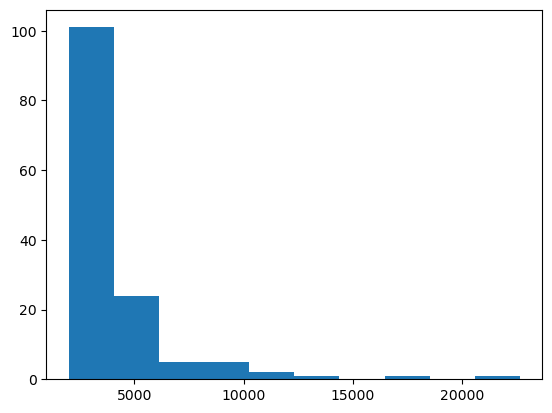

```python
#Sales over 2k
plt.hist(SS_highsales['Sales'])
plt.show()
```

### Inference: The sales over 2k is for over 100 sales

```python
SS_lowsales = SS.loc[SS['Sales'] < 0]
```

```python
SS_lowsales.head()
```

|  | Order ID | Order Date | Ship Date | Ship Mode | Customer ID | Customer Name | Segment | City | State | Postal Code | Region | Product ID | Category | Sub-Category | Product Name | Sales | Quantity | Discount | Profit |
| --- | --- | --- | --- | --- | --- | --- | --- | --- | --- | --- | --- | --- | --- | --- | --- | --- | --- | --- | --- |

### Inference: There are no negative sales, but there are negative profits

### 2. Data Cleaning

```python
SS.shape
```

[output not shown]

```python
SS.columns
```

```
Index(['Row ID', 'Order ID', 'Order Date', 'Ship Date', 'Ship Mode',
       'Customer ID', 'Customer Name', 'Segment', 'Country', 'City', 'State',
       'Postal Code', 'Region', 'Product ID', 'Category', 'Sub-Category',
       'Product Name', 'Sales', 'Quantity', 'Discount', 'Profit'],
      dtype='object')
```

```python
SS.isnull().values.all(axis=0)
```

```
array([False, False, False, False, False, False, False, False, False,
       False, False, False, False, False, False, False, False, False,
       False, False, False])
```

### drop variable: customer name to avoid PII

```python
SS2 = SS.drop(columns = ['Customer Name'])
```

```python
SS2.columns
```

```
Index(['Row ID', 'Order ID', 'Order Date', 'Ship Date', 'Ship Mode',
       'Customer ID', 'Segment', 'Country', 'City', 'State', 'Postal Code',
       'Region', 'Product ID', 'Category', 'Sub-Category', 'Product Name',
       'Sales', 'Quantity', 'Discount', 'Profit'],
      dtype='object')
```

```python
SS2.shape
```

```
(9994, 20)
```

```python
SS.head()
```

|  | Row ID | Order ID | Order Date | Ship Date | Ship Mode | Customer ID | Customer Name | Segment | Country | City | ... | Postal Code | Region | Product ID | Category | Sub-Category | Product Name | Sales | Quantity | Discount | Profit |
| --- | --- | --- | --- | --- | --- | --- | --- | --- | --- | --- | --- | --- | --- | --- | --- | --- | --- | --- | --- | --- | --- |
| 0 | 1 | CA-2016-152156 | 11/8/2016 | 11/11/2016 | Second Class | CG-12520 | Claire Gute | Consumer | United States | Henderson | ... | 42420 | South | FUR-BO-10001798 | Furniture | Bookcases | Bush Somerset Collection Bookcase | 261.9600 | 2 | 0.00 | 41.9136 |
| 1 | 2 | CA-2016-152156 | 11/8/2016 | 11/11/2016 | Second Class | CG-12520 | Claire Gute | Consumer | United States | Henderson | ... | 42420 | South | FUR-CH-10000454 | Furniture | Chairs | Hon Deluxe Fabric Upholstered Stacking Chairs,... | 731.9400 | 3 | 0.00 | 219.5820 |
| 2 | 3 | CA-2016-138688 | 6/12/2016 | 6/16/2016 | Second Class | DV-13045 | Darrin Van Huff | Corporate | United States | Los Angeles | ... | 90036 | West | OFF-LA-10000240 | Office Supplies | Labels | Self-Adhesive Address Labels for Typewriters b... | 14.6200 | 2 | 0.00 | 6.8714 |
| 3 | 4 | US-2015-108966 | 10/11/2015 | 10/18/2015 | Standard Class | SO-20335 | Sean O'Donnell | Consumer | United States | Fort Lauderdale | ... | 33311 | South | FUR-TA-10000577 | Furniture | Tables | Bretford CR4500 Series Slim Rectangular Table | 957.5775 | 5 | 0.45 | -383.0310 |
| 4 | 5 | US-2015-108966 | 10/11/2015 | 10/18/2015 | Standard Class | SO-20335 | Sean O'Donnell | Consumer | United States | Fort Lauderdale | ... | 33311 | South | OFF-ST-10000760 | Office Supplies | Storage | Eldon Fold 'N Roll Cart System | 22.3680 | 2 | 0.20 | 2.5164 |

5 rows × 21 columns

```python
SS.info()
```

```
<class 'pandas.core.frame.DataFrame'>
RangeIndex: 9994 entries, 0 to 9993
Data columns (total 21 columns):
 #   Column         Non-Null Count  Dtype
---  ------         --------------  -----
 0   Row ID         9994 non-null   int64
 1   Order ID       9994 non-null   object
 2   Order Date     9994 non-null   object
 3   Ship Date      9994 non-null   object
 4   Ship Mode      9994 non-null   object
 5   Customer ID    9994 non-null   object
 6   Customer Name  9994 non-null   object
 7   Segment        9994 non-null   object
 8   Country        9994 non-null   object
 9   City           9994 non-null   object
 10  State          9994 non-null   object
 11  Postal Code    9994 non-null   int64
 12  Region         9994 non-null   object
 13  Product ID     9994 non-null   object
 14  Category       9994 non-null   object
 15  Sub-Category   9994 non-null   object
 16  Product Name   9994 non-null   object
 17  Sales          9994 non-null   float64
 18  Quantity       9994 non-null   int64
 19  Discount       9994 non-null   float64
 20  Profit         9994 non-null   float64
dtypes: float64(3), int64(3), object(15)
memory usage: 1.6+ MB
```

### Consistency checks

check for mixed type data  
check for missing data  
check for duplicates

#### mixed type data

```python
#check for mixed types
for col in SS.columns.tolist():
    weird = (SS[[col]].applymap(type) != SS[[col]].iloc[0].apply(type)).any(axis = 1)
    if len (SS[weird]) > 0:
        print(col)
```

#### Observation: There are no mixed data types

#### missing data

```python
# check for missing data
SS.isnull().sum()
```

```
Row ID           0
Order ID         0
Order Date       0
Ship Date        0
Ship Mode        0
Customer ID      0
Customer Name    0
Segment          0
Country          0
City             0
State            0
Postal Code      0
Region           0
Product ID       0
Category         0
Sub-Category     0
Product Name     0
Sales            0
Quantity         0
Discount         0
Profit           0
dtype: int64
```

#### Duplicate check

```python
# check data for duplicates
SS_dup = SS[SS.duplicated()]
```

```python
SS.shape
# No duplicates
```

```
(9994, 21)
```

### 3. Exploring Relationships

### Questions to explore:

Which products have the most and least profit?  
Which products, regions, categories and customer segments should this superstore target or avoid?  
Are the most frequent customers men or women? Which segment?  
Which region is most profitable?  
Which is the most frequent shipping mode and discount?  
What are the most frequently purchases products?  
Which country and city have the most customers?

### First, look at Correlations:

```python
# Create a correlation matrix using pandas

SS.corr()
```

|  | Row ID | Postal Code | Sales | Quantity | Discount | Profit |
| --- | --- | --- | --- | --- | --- | --- |
| Row ID | 1.000000 | 0.009671 | -0.001359 | -0.004016 | 0.013480 | 0.012497 |
| Postal Code | 0.009671 | 1.000000 | -0.023854 | 0.012761 | 0.058443 | -0.029961 |
| Sales | -0.001359 | -0.023854 | 1.000000 | 0.200795 | -0.028190 | 0.479064 |
| Quantity | -0.004016 | 0.012761 | 0.200795 | 1.000000 | 0.008623 | 0.066253 |
| Discount | 0.013480 | 0.058443 | -0.028190 | 0.008623 | 1.000000 | -0.219487 |
| Profit | 0.012497 | -0.029961 | 0.479064 | 0.066253 | -0.219487 | 1.000000 |

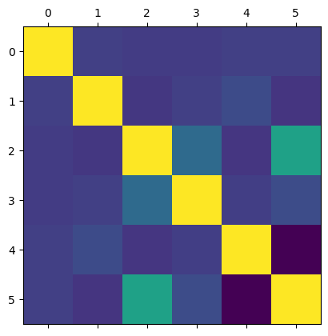

```python
# Create a correlation heatmap using matplotlib

plt.matshow(SS.corr())
plt.show()
```

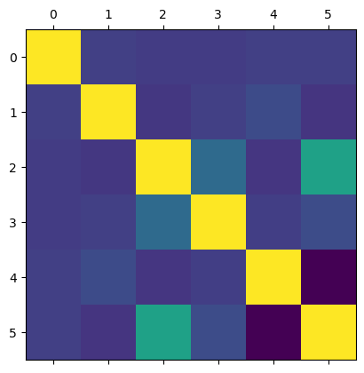

```python
# Save figure
plt.matshow(SS.corr())
plt.savefig("out.png")

# This will save the image in the working directory.
#If you don't know what this directory is the next line will show you how to check
```

```python
#current dir
cwd = os.getcwd()
cwd
```

```
'/Users/margoshogren/Library/CloudStorage/OneDrive-Personal/Documents/Margo-CF Folder-OD/A6 Adv Analytics and Dashboard design'
```

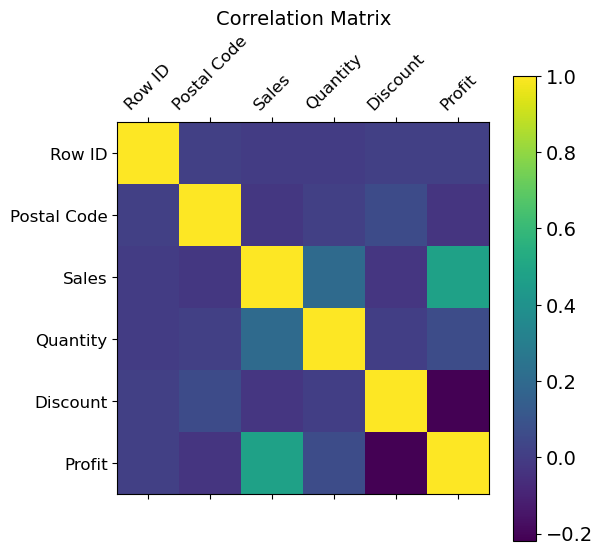

```python
# Add labels, a legend, and change the size of the heatmap for numeric columns

f = plt.figure(figsize=(6, 6)) # figure size
plt.matshow(SS.corr(), fignum=f.number) # type of plot
out = SS.select_dtypes(np.number).quantile()
plt.xticks(range(SS.select_dtypes(['number']).shape[1]), SS.select_dtypes(['number']).columns, fontsize=12, rotation=45) # x axis labels
plt.yticks(range(SS.select_dtypes(['number']).shape[1]), SS.select_dtypes(['number']).columns,fontsize=12) # y axis labels
cb = plt.colorbar() # add a colour legend (called colorbar)
cb.ax.tick_params(labelsize=14) # add font size
plt.title('Correlation Matrix', fontsize=14) # add title
```

### Comment: Sales and Profit have a moderate correlation, quantity and sales has a weak correlation.

#### Create a correlation heatmap using seaborn:

```python
SS.columns
```

```
Index(['Row ID', 'Order ID', 'Order Date', 'Ship Date', 'Ship Mode',
       'Customer ID', 'Customer Name', 'Segment', 'Country', 'City', 'State',
       'Postal Code', 'Region', 'Product ID', 'Category', 'Sub-Category',
       'Product Name', 'Sales', 'Quantity', 'Discount', 'Profit'],
      dtype='object')
```

```python
# create a subset excluding row id
sub = SS[['Postal Code','Sales', 'Quantity', 'Discount', 'Profit']]
```

```python
sub
```

|  | Postal Code | Sales | Quantity | Discount | Profit |
| --- | --- | --- | --- | --- | --- |
| 0 | 42420 | 261.9600 | 2 | 0.00 | 41.9136 |
| 1 | 42420 | 731.9400 | 3 | 0.00 | 219.5820 |
| 2 | 90036 | 14.6200 | 2 | 0.00 | 6.8714 |
| 3 | 33311 | 957.5775 | 5 | 0.45 | -383.0310 |
| 4 | 33311 | 22.3680 | 2 | 0.20 | 2.5164 |
| ... | ... | ... | ... | ... | ... |
| 9989 | 33180 | 25.2480 | 3 | 0.20 | 4.1028 |
| 9990 | 92627 | 91.9600 | 2 | 0.00 | 15.6332 |
| 9991 | 92627 | 258.5760 | 2 | 0.20 | 19.3932 |
| 9992 | 92627 | 29.6000 | 4 | 0.00 | 13.3200 |
| 9993 | 92683 | 243.1600 | 2 | 0.00 | 72.9480 |

9994 rows × 5 columns

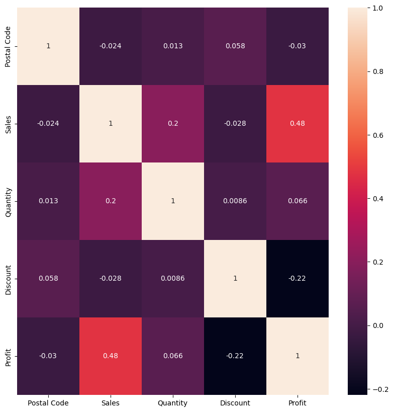

```python
# Create a subplot with matplotlib
f,ax = plt.subplots(figsize=(10,10))

# Create the correlation heatmap in seaborn by applying a heatmap onto the correlation matrix and the subplots defined above.
corr = sns.heatmap(sub.corr(), annot = True, ax = ax) # The `annot` argument allows the plot to
#place the correlation coefficients onto the heatmap.
```

### Comment: Sales and Profit have a moderate correlation, quantity and sales has a weak correlation.¶

Discount and profit show a negative relationship

### Scatterplots:

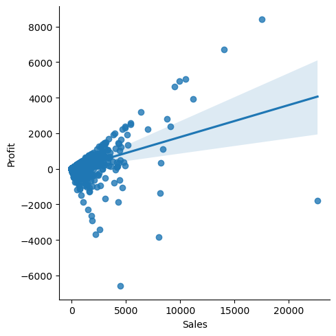

```python
# Create a scatterplot for the "Sales" and "profit" columns in seaborn

sns.lmplot(x = 'Sales', y = 'Profit', data = SS)
```

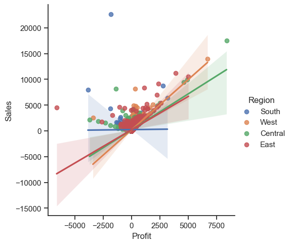

```python
# Create a scatterplot for the "Sales" and "profit" columns in seaborn

sns.lmplot(x = 'Profit', y = 'Sales',hue= 'Region', data = SS)
```

### The West (orange) is highest profit region

### Pair Plots:

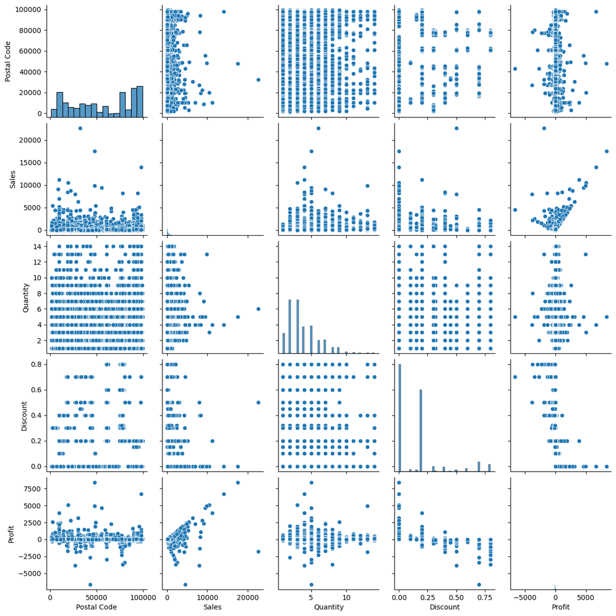

```python
# Create a pair plot

g = sns.pairplot(sub)
```

### Categorical Plots:

#### Creating a categorical variable that splits the "Profit" column into categories¶

### * Question: Which is the most frequent discount?

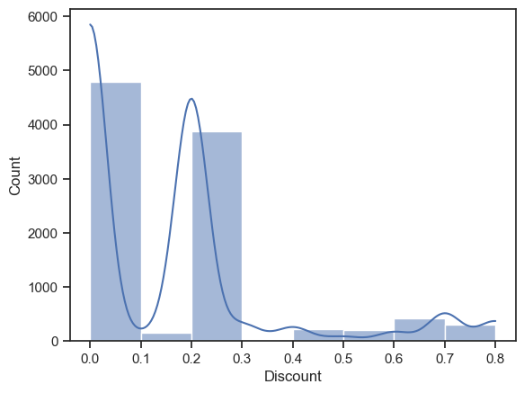

```python
# Use a histogram to visualize the distribution of the variables.
# This way, you can determine sensible categories for the profits.
# You don't want to end up with too few observations in any one of the categories.
# The argument "kde" add a line that encompasses the distribution

sns.histplot(SS['Discount'], bins = 8, kde = True)
```

### Most discount is under 10% and 20-30%

```python
SS['Postal Code'].value_counts().sort_index(ascending=False).sort_values(ascending=False)
```

```
10035    263
10024    230
10009    229
94122    203
10011    193
        ...
60025      1
60004      1
59801      1
59102      1
1040       1
Name: Postal Code, Length: 631, dtype: int64
```

```python
zip_high = SS[SS['Postal Code'].isin([10035,10024,10009,94122])]
```

```python
zip_high = zip_high.groupby('Postal Code').sum()
```

```python
print(zip_high[['Postal Code','State','City']])
```

[output not shown]

```python
zip_high['Postal Code'].value_counts().sort_index(ascending=False).sort_values(ascending=False)
```

[output not shown]

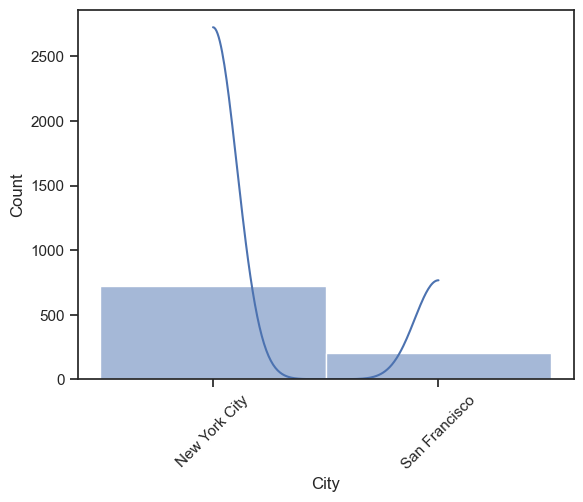

```python
sns.histplot(zip_high['City'], bins = 8, kde = True)
plt.xticks (rotation= 45)
plt.show()
```

### The top 2 cities with the most zip codes in the database.

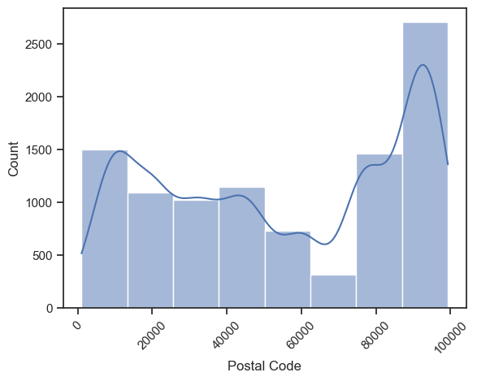

```python
sns.histplot(SS['Postal Code'], bins = 8, kde = True)
plt.xticks (rotation= 45)
plt.show()
#g.set_axis_labels("Bill length (mm)", "Bill depth (mm)", labelpad=10)
```

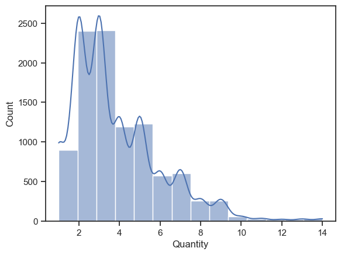

```python
sns.histplot(SS['Quantity'], bins = 14, kde = True)
```

### The most common quantities are under 4

### * Question: What segment should the Superstore target or avoid?

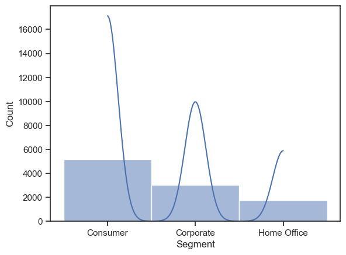

```python
sns.histplot(SS['Segment'], bins = 10, kde = True)
```

#### Observation: Highest segment is Consumer followed by Corporate

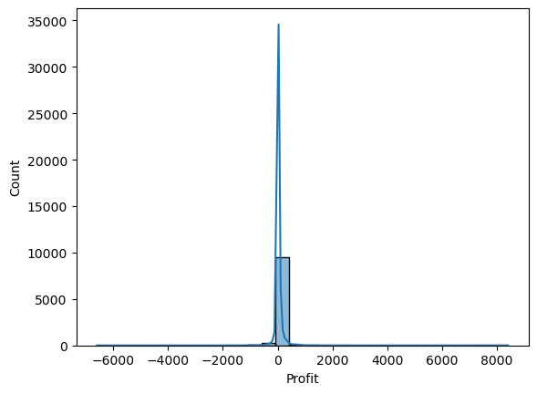

```python
sns.histplot(SS['Profit'], bins = 30, kde = True)
```

### Observation: the profit has a few very high values causing a wide range of deviation.

```python
SS.loc[SS['Profit'] < 0, 'Profit category'] = 'Low profit'
```

```python
SS.loc[(SS['Profit'] >= 0) & (SS['Profit'] < 2500), 'Profit category'] = 'Middle profit'
```

```python
SS.loc[SS['Profit'] >= 2500, 'Profit category'] = 'High profit'
```

```python
SS['Profit category'].value_counts()
```

[output not shown]

```python
SS['Profit'].describe()
```

```
count    9994.000000
mean       28.656896
std       234.260108
min     -6599.978000
25%         1.728750
50%         8.666500
75%        29.364000
max      8399.976000
Name: Profit, dtype: float64
```

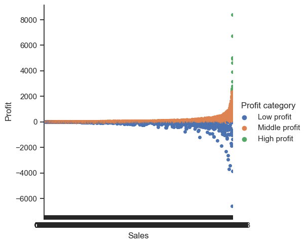

```python
# Create a categorical plot in seaborn using the profit categories created above

sns.set(style="ticks")
g = sns.catplot(x="Sales", y="Profit", hue="Profit category", data=SS)
plt.xlabel('Sales')
plt.show()
```

### create sub categories of the profit for High, Medium, Low profit

### * Question: Which products have the most and least profit?

### High profit products

```python
sub_high = SS[SS['Profit category']=='High profit'].groupby(['Category','Product Name'],as_index=False)[['Sales','Profit']].sum()
sub_high.sort_values(by=['Profit'],ascending=False,inplace=True)
sub_high.head(45)
```

|  | Category | Product Name | Sales | Profit |
| --- | --- | --- | --- | --- |
| 4 | Technology | Canon imageCLASS 2200 Advanced Copier | 53199.848 | 24079.9312 |
| 2 | Office Supplies | GBC Ibimaster 500 Manual ProClick Binding System | 9892.740 | 4946.3700 |
| 3 | Office Supplies | Ibico EPK-21 Electric Binding System | 9449.950 | 4630.4755 |
| 0 | Office Supplies | Fellowes PB500 Electric Punch Plastic Comb Bin... | 6354.950 | 3177.4750 |
| 5 | Technology | HP Designjet T520 Inkjet Large Format Printer ... | 8749.950 | 2799.9840 |
| 6 | Technology | Hewlett Packard LaserJet 3310 Copier | 5399.910 | 2591.9568 |
| 1 | Office Supplies | GBC DocuBind P400 Electric Binding System | 5443.960 | 2504.2216 |

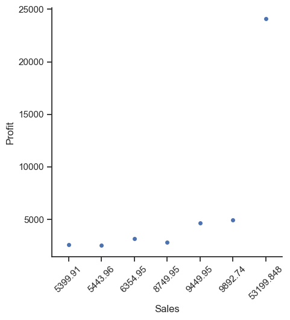

```python
# Create a categorical plot in seaborn using the high profit category created above

sns.set(style="ticks")
g = sns.catplot(x="Sales", y="Profit",data=sub_high)
plt.xticks(rotation=45)
plt.show()
```

### Low profit products?

```python
sub_low = SS[SS['Profit category']=='Low profit'].groupby(['Category','Product Name'],as_index=False)[['Sales','Profit']].sum()
sub_low.sort_values(by=['Profit'],ascending=True,inplace=True)
sub_low.head(45)
```

|  | Category | Product Name | Sales | Profit |
| --- | --- | --- | --- | --- |
| 639 | Technology | Cubify CubeX 3D Printer Double Head Print | 6299.9790 | -9239.9692 |
| 419 | Office Supplies | GBC DocuBind P400 Electric Binding System | 4899.5640 | -6859.3896 |
| 678 | Technology | Lexmark MX611dhe Monochrome Laser Printer | 13769.9190 | -5269.9690 |
| 424 | Office Supplies | GBC Ibimaster 500 Manual ProClick Binding System | 6696.6240 | -5098.5660 |
| 422 | Office Supplies | GBC DocuBind TL300 Electric Binding System | 4395.2510 | -4162.0336 |
| 640 | Technology | Cubify CubeX 3D Printer Triple Head Print | 7999.9800 | -3839.9904 |
| 403 | Office Supplies | Fellowes PB500 Electric Punch Plastic Comb Bin... | 2287.7820 | -3431.6730 |
| 52 | Furniture | Chromcraft Bull-Nose Wood Oval Conference Tabl... | 8264.7000 | -3107.5272 |
| 481 | Office Supplies | Ibico EPK-21 Electric Binding System | 1889.9900 | -2929.4845 |
| 33 | Furniture | Bush Advantage Collection Racetrack Conference... | 6151.0450 | -2545.2600 |
| 233 | Furniture | Riverside Palais Royal Lawyers Bookcase, Royal... | 5479.6956 | -1982.2050 |
| 482 | Office Supplies | Ibico Hi-Tech Manual Binding System | 1189.4610 | -1829.9400 |
| 634 | Technology | Cisco TelePresence System EX90 Videoconferenci... | 22638.4800 | -1811.0784 |
| 417 | Office Supplies | GBC DocuBind 300 Electric Binding Machine | 1946.1260 | -1609.4988 |
| 13 | Furniture | Balt Solid Wood Round Tables | 2946.8340 | -1522.5309 |
| 501 | Office Supplies | Martin Yale Chadless Opener Electric Letter Op... | 6662.4800 | -1499.0580 |
| 274 | Office Supplies | 3.6 Cubic Foot Counter Height Office Refrigerator | 530.3160 | -1378.8216 |
| 20 | Furniture | Bevis Oval Conference Table, Walnut | 4071.2880 | -1344.0470 |
| 438 | Office Supplies | GBC ProClick 150 Presentation Binding System | 884.7440 | -1292.3582 |
| 231 | Furniture | Riverside Furniture Oval Coffee Table, Oval En... | 4159.3250 | -1210.5070 |
| 478 | Office Supplies | Hoover Upright Vacuum With Dirt Cup | 463.2480 | -1181.2824 |
| 31 | Furniture | Bretford Rectangular Conference Table Tops | 4344.3015 | -1158.4804 |
| 28 | Furniture | BoxOffice By Design Rectangular and Half-Moon ... | 1706.2500 | -1148.4375 |
| 147 | Furniture | HON 5400 Series Task Chairs for Big and Tall | 7850.9760 | -1121.5680 |
| 32 | Furniture | Bretford Just In Time Height-Adjustable Mult... | 3965.3000 | -1081.0660 |
| 647 | Technology | Epson TM-T88V Direct Thermal Printer - Monochr... | 1212.7050 | -1057.2300 |
| 210 | Furniture | O'Sullivan 4-Shelf Bookcase in Odessa Pine | 1161.4080 | -1047.6868 |
| 161 | Furniture | Hon 94000 Series Round Tables | 3554.1600 | -1027.7446 |
| 565 | Office Supplies | Tennsco Single-Tier Lockers | 5404.8960 | -1013.4180 |
| 150 | Furniture | Hon 2090 Pillow Soft Series Mid Back Swivel/... | 5282.4240 | -989.0496 |
| 29 | Furniture | Bretford CR4500 Series Slim Rectangular Table | 4387.4460 | -974.9880 |
| 627 | Technology | Cisco 9971 IP Video Phone Charcoal | 1188.0000 | -950.4000 |
| 657 | Technology | HP Designjet T520 Inkjet Large Format Printer ... | 2624.9850 | -944.9946 |
| 760 | Technology | Zebra GK420t Direct Thermal/Thermal Transfer P... | 703.7100 | -938.2800 |
| 51 | Furniture | Chromcraft Bull-Nose Wood 48" x 96" Rectangula... | 2644.7040 | -925.6464 |
| 50 | Furniture | Chromcraft 48" x 96" Racetrack Double Pedestal... | 2340.6720 | -910.6176 |
| 159 | Furniture | Hon 5100 Series Wood Tables | 2473.3300 | -867.1204 |
| 749 | Technology | Swingline SM12-08 MicroCut Jam Free Shredder | 1079.9730 | -863.9784 |
| 11 | Furniture | BPI Conference Tables | 1949.7675 | -854.3925 |
| 748 | Technology | StarTech.com 10/100 VDSL2 Ethernet Extender Kit | 1797.9300 | -839.0340 |
| 9 | Furniture | Atlantic Metals Mobile 4-Shelf Bookcases, Cust... | 590.0580 | -786.7440 |
| 463 | Office Supplies | High Speed Automatic Electric Letter Opener | 3930.0720 | -786.0144 |
| 218 | Furniture | O'Sullivan Plantations 2-Door Library in Landv... | 2946.3668 | -767.7436 |
| 170 | Furniture | Hon Racetrack Conference Tables | 2966.3630 | -766.5292 |
| 216 | Furniture | O'Sullivan Living Dimensions 5-Shelf Bookcases | 3420.7704 | -755.7516 |

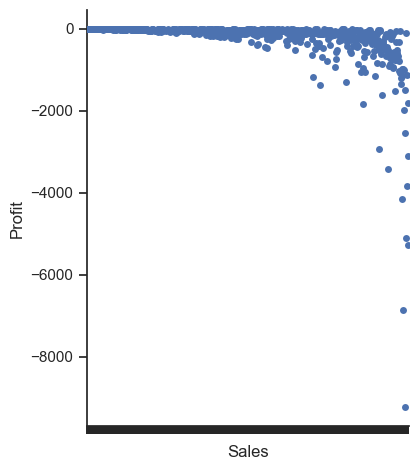

```python
# Create a categorical plot in seaborn using the low profit category created above

sns.set(style="ticks")
g = sns.catplot(x="Sales", y="Profit",data=sub_low)
plt.xticks(rotation=45)
g.set(xticklabels=[])
plt.show()
```

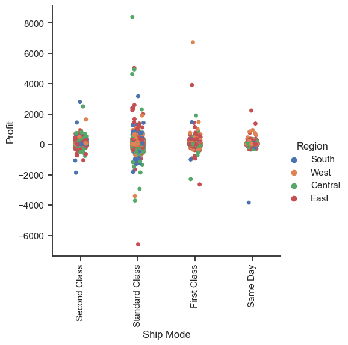

```python
# Create a categorical plot in seaborn using the high profit category created above

sns.set(style="ticks")
g = sns.catplot(x="Ship Mode", y="Profit",data=SS, hue='Region')
plt.xticks(rotation=90)
plt.show()
```

### * Question: Which region is most and least profitable?

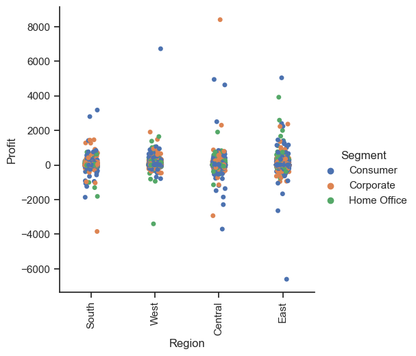

```python
# Create a categorical plot in seaborn using the high profit category created above

sns.set(style="ticks")
g = sns.catplot(x='Region', y="Profit",data=SS, hue='Segment')
plt.xticks(rotation=90)
plt.show()
```

```python
# What are the profits per region?
SS.groupby('Region')['Profit'].sum().sort_values(ascending=False)
```

```
Region
West       108418.4489
East        91522.7800
South       46749.4303
Central     39706.3625
Name: Profit, dtype: float64
```

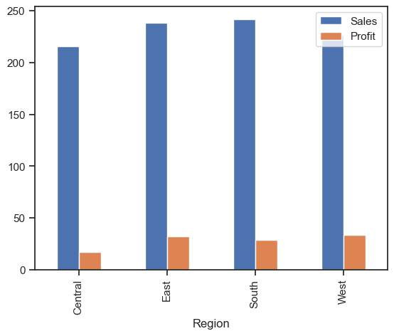

```python
# Group the data by Region
region_group = SS.groupby(["Region"]).mean()[["Sales", "Profit"]]

# Ploting
region_group.plot(kind="bar")

plt.show()
```

### Inference: The West and East have highest average profit and the South and East have highest average Sales

```python
# what are the most frequently purchased products?
SS['Product Name'].value_counts().sort_values(ascending=False)[:10]
```

```
Staple envelope                               48
Staples                                       46
Easy-staple paper                             46
Avery Non-Stick Binders                       20
Staples in misc. colors                       19
Staple remover                                18
KI Adjustable-Height Table                    18
Storex Dura Pro Binders                       17
Staple-based wall hangings                    16
Situations Contoured Folding Chairs, 4/Set    15
Name: Product Name, dtype: int64
```

### Hypothesis to explore: There are products with negative profit that are affecting the Superstores overall profit, perhaps from discounts?

### More to explore: How were sales and profit changed over time?

### Extreme value check

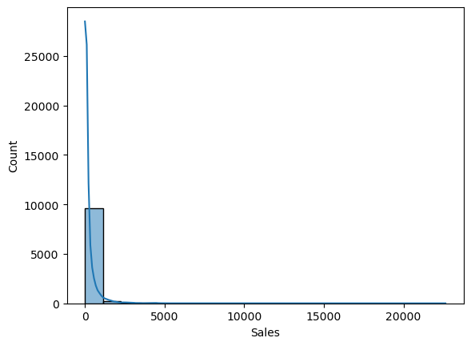

```python
#histogram for Sales, profit, discount the continuous variables
sns.histplot(SS['Sales'], bins=20,kde=True)
```

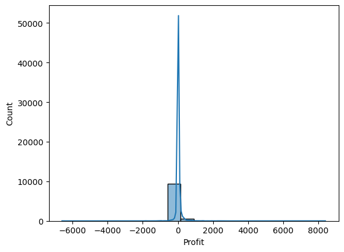

```python
sns.histplot(SS['Profit'], bins=20,kde=True)
```

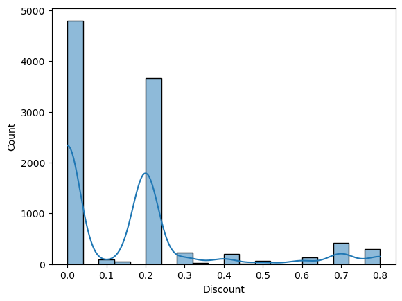

```python
sns.histplot(SS['Discount'], bins=20,kde=True)
```

## Plotting a choropleth

```python
# That's just in case you want to look at the JSON file contents here too:

f = open(r'/Users/margoshogren/Library/CloudStorage/OneDrive-Personal/Documents/Margo-CF Folder-OD/A6 Adv Analytics and Dashboard design/6_3 Geographical visualizations with Python/us-states.json',)

# returns JSON object asa dictionary
data = json.load(f)

# Iterating through the json list
for i in data['features']:
    print(i)
```

[output not shown]

[output cut: 36 more lines]

```python
SS['State'].unique()
```

```
array(['Kentucky', 'California', 'Florida', 'North Carolina',
       'Washington', 'Texas', 'Wisconsin', 'Utah', 'Nebraska',
       'Pennsylvania', 'Illinois', 'Minnesota', 'Michigan', 'Delaware',
       'Indiana', 'New York', 'Arizona', 'Virginia', 'Tennessee',
       'Alabama', 'South Carolina', 'Oregon', 'Colorado', 'Iowa', 'Ohio',
       'Missouri', 'Oklahoma', 'New Mexico', 'Louisiana', 'Connecticut',
       'New Jersey', 'Massachusetts', 'Georgia', 'Nevada', 'Rhode Island',
       'Mississippi', 'Arkansas', 'Montana', 'New Hampshire', 'Maryland',
       'District of Columbia', 'Kansas', 'Vermont', 'Maine',
       'South Dakota', 'Idaho', 'North Dakota', 'Wyoming',
       'West Virginia'], dtype=object)
```

```python
# Select only the necessary columns and put them in a list called columns

columns =['Kentucky', 'California', 'Florida', 'North Carolina',
       'Washington', 'Texas', 'Wisconsin', 'Utah', 'Nebraska',
       'Pennsylvania', 'Illinois', 'Minnesota', 'Michigan', 'Delaware',
       'Indiana', 'New York', 'Arizona', 'Virginia', 'Tennessee',
       'Alabama', 'South Carolina', 'Oregon', 'Colorado', 'Iowa', 'Ohio',
       'Missouri', 'Oklahoma', 'New Mexico', 'Louisiana', 'Connecticut',
       'New Jersey', 'Massachusetts', 'Georgia', 'Nevada', 'Rhode Island',
       'Mississippi', 'Arkansas', 'Montana', 'New Hampshire', 'Maryland',
       'District of Columbia', 'Kansas', 'Vermont', 'Maine',
       'South Dakota', 'Idaho', 'North Dakota', 'Wyoming',
       'West Virginia', 'Sales','Profit']
```

```python
# Create a data frame with just the states and the values for rating we want plotted
data_to_plot = SS.groupby(['State'])['Profit'].sum()
```

```python
# Create a data frame with just the states and the values for rating we want plotted

data_to_plot.head(49)
```

```
State
Alabama                  5786.8253
Arizona                 -3427.9246
Arkansas                 4008.6871
California              76381.3871
Colorado                -6527.8579
Connecticut              3511.4918
Delaware                 9977.3748
District of Columbia     1059.5893
Florida                 -3399.3017
Georgia                 16250.0433
Idaho                     826.7231
Illinois               -12607.8870
Indiana                 18382.9363
Iowa                     1183.8119
Kansas                    836.4435
Kentucky                11199.6966
Louisiana                2196.1023
Maine                     454.4862
Maryland                 7031.1788
Massachusetts            6785.5016
Michigan                24463.1876
Minnesota               10823.1874
Mississippi              3172.9762
Missouri                 6436.2105
Montana                  1833.3285
Nebraska                 2037.0942
Nevada                   3316.7659
New Hampshire            1706.5028
New Jersey               9772.9138
New Mexico               1157.1161
New York                74038.5486
North Carolina          -7490.9122
North Dakota              230.1497
Ohio                   -16971.3766
Oklahoma                 4853.9560
Oregon                  -1190.4705
Pennsylvania           -15559.9603
Rhode Island             7285.6293
South Carolina           1769.0566
South Dakota              394.8283
Tennessee               -5341.6936
Texas                  -25729.3563
Utah                     2546.5335
Vermont                  2244.9783
Virginia                18597.9504
Washington              33402.6517
West Virginia             185.9216
Wisconsin                8401.8004
Wyoming                   100.1960
Name: Profit, dtype: float64
```

```python
# Setup a folium map at a high-level zoom
map = folium.Map(location = [100, 0], zoom_start = 1.5)

# Choropleth maps bind Pandas Data Frames and json geometries.This allows us to quickly visualize data combinations
folium.Choropleth(
    geo_data = country_geo,
    data = data_to_plot,
    columns = ['State', 'Profit'],
    key_on = 'feature.properties.name', # this part is very important - check your json file to see where the KEY is located
    fill_color = 'YlOrBr', fill_opacity=0.6, line_opacity=0.1,
    legend_name = "Profit").add_to(map)
folium.LayerControl().add_to(map)

map
```

Make this Notebook Trusted to load map: File -> Trust Notebook

[interactive chart not shown]

### Inference: CA and NY are the 2 states that stand out with highest profit

```python
SSSP= data_to_plot.groupby('State')['Profit'].sum()
```

```python
SSSP.sort_values(ascending=False)[:5]
```

```
State
California    76381.3871
New York      74038.5486
Washington    33402.6517
Michigan      24463.1876
Virginia      18597.9504
Name: Profit, dtype: float64
```

```python
# fig = g.get_figure()
g.savefig("out.png")
```

```python
# end of 6.3
```